# R语言与机器学习（上）

### 模型复杂度与偏差-方差的关系

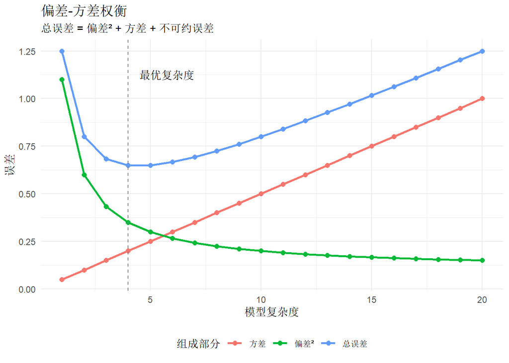

```r
# 模型复杂度与偏差/方差的关系
complexity <- 1:20
bias_squared <- 1 / complexity + 0.1  # 偏差随复杂度降低
variance <- complexity / 20  # 方差随复杂度增加
total_error <- bias_squared + variance + 0.1  # 总误差

bv_data <- data.frame(
  complexity = rep(complexity, 3),
  value = c(bias_squared, variance, total_error),
  component = rep(c("偏差²", "方差", "总误差"), each = length(complexity))
)

ggplot2::ggplot(bv_data, ggplot2::aes(x = complexity, y = value, color = component)) +
  ggplot2::geom_line(linewidth = 1) +
  ggplot2::geom_point(size = 2) +
  ggplot2::geom_vline(xintercept = which.min(total_error), linetype = "dashed", color = "gray50") +
  ggplot2::annotate("text", x = which.min(total_error) + 0.5, y = max(bv_data$value) * 0.9,
                    label = "最优复杂度", hjust = 0) +
  ggplot2::labs(
    title = "偏差-方差权衡",
    subtitle = "总误差 = 偏差² + 方差 + 不可约误差",
    x = "模型复杂度", y = "误差", color = "组成部分"
  ) +
  ggplot2::theme_minimal() +
  ggplot2::theme(legend.position = "bottom")
```

### 不同算法的偏差-方差特点

| 算法类型 | 偏差 | 方差 | 特点 |
| --- | --- | --- | --- |
| 线性回归 | 高 | 低 | 简单稳定，但可能欠拟合 |
| 决策树（深） | 低 | 高 | 复杂灵活，但容易过拟合 |
| 随机森林 | 中 | 低 | 集成降低方差 |
| Boosting | 低 | 中 | 集成降低偏差 |

### 意义与使用场景

**核心意义**：偏差-方差权衡是机器学习的核心矛盾，需要在模型复杂度上找到平衡点。

**举例**：选择疾病预测模型

**高偏差模型（如简单逻辑回归）**：

只用年龄预测糖尿病风险。模型稳定（低方差），但预测不够准确（高偏差），因为忽略了BMI、血糖等重要因素。

**高方差模型（如深度决策树）**：

使用包含100个特征的深度决策树。在训练集上完美预测，但换一批患者后预测结果变化很大（高方差），因为模型过度拟合了训练数据的特殊模式。

**如何权衡？**

选择随机森林或梯度提升树，通过集成学习在偏差和方差之间取得平衡。同时使用交叉验证选择最优超参数。

## 1.9 模型泛化能力

### 核心概念

**泛化能力（Generalization）**：模型在未见数据上的表现能力。

**泛化误差（Generalization Error）**：模型在新数据上的期望误差。

$$\text{泛化误差} = E_{(x,y) \sim P} [L(y,
\hat{f}(x))]$$

其中 $P$ 是数据的真实分布，$L$ 是损失函数。

### 泛化的核心问题

**训练误差 vs 泛化误差**：

- **训练误差**：模型在训练数据上的误差
- **泛化误差**：模型在所有可能数据上的期望误差

**目标**：最小化泛化误差，而非训练误差。

[figure not shown]

```r
# 泛化能力示意图
# 使用不同大小的训练集演示

set.seed(42)

# 生成数据
n_total <- 1000
x_all <- runif(n_total, 0, 10)
y_all <- 2 * x_all + 1 + rnorm(n_total, sd = 2)  # 真实关系: y = 2x + 1 + 噪声
all_data <- data.frame(x = x_all, y = y_all)

# 测试集（固定）
test_idx <- sample(1:n_total, 200)
test_data <- all_data[test_idx, ]
train_pool <- all_data[-test_idx, ]

# 不同训练集大小下的训练误差和测试误差
train_sizes <- c(20, 50, 100, 200, 400, 600, 800)
results <- data.frame()

for (n_train in train_sizes) {
  # 多次实验取平均
  train_errors <- c()
  test_errors <- c()

  for (i in 1:10) {
    idx <- sample(1:nrow(train_pool), n_train)
    train_data <- train_pool[idx, ]

    model <- lm(y ~ x, data = train_data)

    train_errors <- c(train_errors, mean((train_data$y - predict(model, train_data))^2))
    test_errors <- c(test_errors, mean((test_data$y - predict(model, test_data))^2))
  }

  results <- rbind(results, data.frame(
    train_size = n_train,
    train_error = mean(train_errors),
    test_error = mean(test_errors)
  ))
}

# 可视化
results_long <- tidyr::pivot_longer(results, cols = c(train_error, test_error),
                                     names_to = "type", values_to = "error")

ggplot2::ggplot(results_long, ggplot2::aes(x = train_size, y = error, color = type)) +
  ggplot2::geom_line(linewidth = 1) +
  ggplot2::geom_point(size = 2) +
  ggplot2::labs(
    title = "训练数据量与泛化能力的关系",
    subtitle = "随着训练数据增加，训练误差和测试误差趋于接近",
    x = "训练样本数量", y = "均方误差（MSE）", color = ""
  ) +
  ggplot2::scale_color_discrete(labels = c("训练误差", "测试误差（泛化误差估计）")) +
  ggplot2::theme_minimal() +
  ggplot2::theme(legend.position = "bottom")
```

### 提高泛化能力的方法

| 方法 | 原理 | 适用场景 |
| --- | --- | --- |
| 增加训练数据 | 减少过拟合 | 数据不足时 |
| 正则化 | 限制模型复杂度 | 过拟合时 |
| 交叉验证 | 更准确估计泛化误差 | 模型选择时 |
| 特征选择 | 减少噪声特征 | 特征过多时 |
| 集成学习 | 降低方差 | 单模型不稳定时 |

### 泛化误差界

根据统计学习理论，泛化误差有理论上界：

$$\text{泛化误差} \leq \text{训练误差} +
\sqrt{\frac{d \log(n/d) + \log(1/\delta)}{n}}$$

其中： - $d$：模型复杂度（如VC维） - $n$：训练样本数 - $\delta$：置信度

**启示**： 1. 模型越复杂，泛化误差上界越大 2. 训练数据越多，泛化误差上界越小

### 意义与使用场景

**核心意义**：泛化能力是机器学习模型的终极目标，模型的价值在于对未知数据的预测能力。

**举例**：医学诊断模型的临床应用

**训练场景**：在A医院的历史数据上训练肺癌诊断模型，训练集准确率95%。

**泛化问题**：当模型部署到B医院时，准确率可能下降到80%。原因包括：A、B医院的患者人群不同、设备差异、诊断标准差异等。

**如何提高泛化能力？**

1. 多中心数据训练：使用多家医院的数据
2. 数据增强：增加数据的多样性
3. 正则化：防止模型过度拟合特定医院的特点
4. 域适应：针对新医院的数据进行调整

## 1.10 学习曲线（learning curve）

### 核心概念

**学习曲线**：展示模型性能随训练数据量变化的曲线。

**用途**： 1. 诊断模型是否过拟合/欠拟合 2. 判断增加数据是否有帮助 3. 确定最优训练数据量

### 学习曲线的典型形态

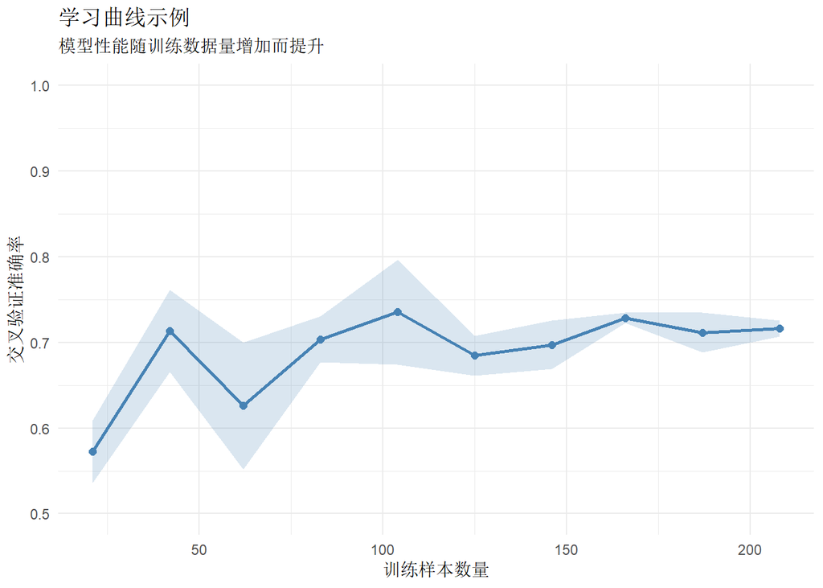

```r
# 学习曲线示例
# 使用caret包绘制学习曲线

set.seed(42)

# 加载数据
data(Sonar, package = "mlbench")

# 定义训练控制
train_control <- caret::trainControl(
  method = "cv",
  number = 5
)

# 计算不同训练集大小下的性能
train_sizes <- seq(0.1, 1, by = 0.1)
n <- nrow(Sonar)

results <- data.frame()

for (prop in train_sizes) {
  n_train <- round(prop * n)

  # 多次采样取平均
  accs <- c()
  for (i in 1:5) {
    idx <- sample(1:n, n_train)
    train_subset <- Sonar[idx, ]

    model <- caret::train(
      Class ~ .,
      data = train_subset,
      method = "rpart",
      trControl = train_control,
      tuneLength = 3
    )

    accs <- c(accs, max(model$results$Accuracy))
  }

  results <- rbind(results, data.frame(
    train_size = n_train,
    accuracy = mean(accs),
    sd = sd(accs)
  ))
}

# 绘制学习曲线
ggplot2::ggplot(results, ggplot2::aes(x = train_size, y = accuracy)) +
  ggplot2::geom_line(color = "steelblue", linewidth = 1) +
  ggplot2::geom_point(color = "steelblue", size = 2) +
  ggplot2::geom_ribbon(ggplot2::aes(ymin = accuracy - sd, ymax = accuracy + sd),
                       alpha = 0.2, fill = "steelblue") +
  ggplot2::labs(
    title = "学习曲线示例",
    subtitle = "模型性能随训练数据量增加而提升",
    x = "训练样本数量", y = "交叉验证准确率"
  ) +
  ggplot2::theme_minimal() +
  ggplot2::ylim(0.5, 1)
```

### 不同情况下的学习曲线

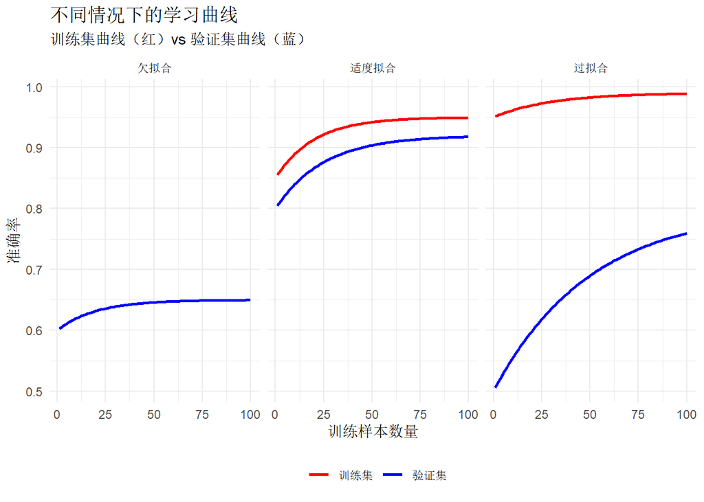

```r
# 模拟不同情况的学习曲线

train_sizes <- 1:100

# 欠拟合：性能低且平稳
underfit_curve <- 0.6 + 0.05 * (1 - exp(-train_sizes / 20))

# 过拟合：训练性能高，验证性能低
overfit_train <- 0.95 + 0.04 * (1 - exp(-train_sizes / 30))
overfit_val <- 0.5 + 0.3 * (1 - exp(-train_sizes / 50))

# 适度拟合：两条曲线接近
good_fit_train <- 0.85 + 0.1 * (1 - exp(-train_sizes / 20))
good_fit_val <- 0.8 + 0.12 * (1 - exp(-train_sizes / 25))

# 创建数据框
lc_data <- data.frame(
  train_size = rep(train_sizes, 6),
  accuracy = c(underfit_curve, underfit_curve,
               overfit_train, overfit_val,
               good_fit_train, good_fit_val),
  type = rep(c("欠拟合", "过拟合", "适度拟合"), each = 200),
  curve = rep(rep(c("训练集", "验证集"), each = 100), 3)
)

lc_data$type <- factor(lc_data$type, levels = c("欠拟合", "适度拟合", "过拟合"))

# 绘制
ggplot2::ggplot(lc_data, ggplot2::aes(x = train_size, y = accuracy, color = curve)) +
  ggplot2::geom_line(linewidth = 1) +
  ggplot2::facet_wrap(~ type) +
  ggplot2::labs(
    title = "不同情况下的学习曲线",
    subtitle = "训练集曲线（红）vs 验证集曲线（蓝）",
    x = "训练样本数量", y = "准确率", color = ""
  ) +
  ggplot2::scale_color_manual(values = c("训练集" = "red", "验证集" = "blue")) +
  ggplot2::theme_minimal() +
  ggplot2::theme(legend.position = "bottom")
```

### 如何解读学习曲线？

| 曲线特征 | 诊断 | 建议 |
| --- | --- | --- |
| 训练和验证曲线都低且接近 | 欠拟合 | 增加模型复杂度 |
| 训练曲线高，验证曲线低 | 过拟合 | 增加数据、正则化 |
| 曲线仍在上升 | 数据不足 | 继续收集数据 |
| 曲线已平稳 | 数据充足 | 无需更多数据 |

## 1.11 交叉验证（K折、留一、分层K折）

### 核心概念

**交叉验证（Cross-Validation）**：将数据分成多份，轮流用其中一份做验证、其余做训练，综合评估模型性能。

**目的**：更充分地利用数据，获得更稳定的性能估计。

### K折交叉验证（K-Fold CV）

**方法**：将数据分成K份，进行K次训练和验证，每次用其中1份验证、其余K-1份训练。

**数学表达**：

$$CV_{(K)} = \frac{1}{K} \sum_{i=1}^{K}
E_i$$

其中 $E_i$ 是第 $i$ 折的验证误差。

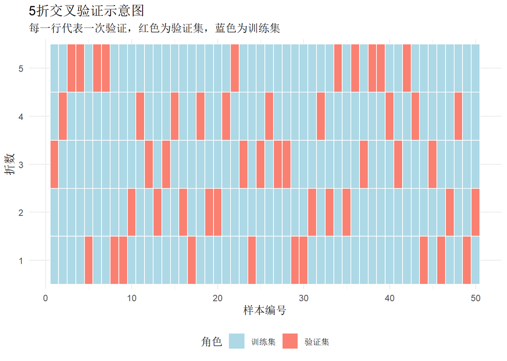

```r
# K折交叉验证示意图
# 使用5折交叉验证演示

set.seed(42)
n <- 50
data <- data.frame(
  id = 1:n,
  value = rnorm(n)
)

# 创建5折划分
k <- 5
folds <- sample(rep(1:k, length.out = n))

# 可视化交叉验证过程
cv_viz <- data.frame(
  id = rep(1:n, k),
  fold = rep(1:k, each = n),
  role = rep(folds, k)
)

for (i in 1:k) {
  cv_viz$role[(i-1)*n + 1:n] <- ifelse(folds == i, "验证集", "训练集")
}

cv_viz$fold <- factor(cv_viz$fold)

ggplot2::ggplot(cv_viz, ggplot2::aes(x = id, y = fold, fill = role)) +
  ggplot2::geom_tile(color = "white", linewidth = 0.5) +
  ggplot2::scale_fill_manual(values = c("训练集" = "lightblue", "验证集" = "salmon")) +
  ggplot2::labs(
    title = "5折交叉验证示意图",
    subtitle = "每一行代表一次验证，红色为验证集，蓝色为训练集",
    x = "样本编号", y = "折数", fill = "角色"
  ) +
  ggplot2::theme_minimal() +
  ggplot2::theme(legend.position = "bottom")
```

### 使用caret包进行交叉验证

```r
# 使用caret包进行K折交叉验证
set.seed(42)

# 定义交叉验证控制
cv_control <- caret::trainControl(
  method = "cv",        # K折交叉验证
  number = 5,           # 5折
  verboseIter = FALSE   # 不显示每次迭代的进度
)

# 训练模型（使用5折交叉验证）
model_cv <- caret::train(
  Species ~ .,
  data = iris,
  method = "rpart",
  trControl = cv_control,
  tuneLength = 3
)

# 查看交叉验证结果
print(model_cv)
```

```
## CART
##
## 150 samples
##   4 predictor
##   3 classes: 'setosa', 'versicolor', 'virginica'
##
## No pre-processing
## Resampling: Cross-Validated (5 fold)
## Summary of sample sizes: 120, 120, 120, 120, 120
## Resampling results across tuning parameters:
##
##   cp    Accuracy   Kappa
##   0.00  0.9400000  0.91
##   0.44  0.7600000  0.64
##   0.50  0.3333333  0.00
##
## Accuracy was used to select the optimal model using the largest value.
## The final value used for the model was cp = 0.
```

### 留一交叉验证（Leave-One-Out CV, LOOCV）

**方法**：每次留一个样本做验证，其余全部做训练。适用于小样本数据。

**特点**： 1. 估计最准确（偏差最小） 2. 计算成本高（需要训练n次） 3. 方差可能较大

```r
# LOOCV示例
# 使用caret包
set.seed(42)

loocv_control <- caret::trainControl(
  method = "LOOCV"  # 留一交叉验证
)

# 训练模型（使用LOOCV）
model_loocv <- caret::train(
  Species ~ .,
  data = iris,
  method = "rpart",
  trControl = loocv_control
)

# 查看结果
cat("LOOCV准确率：", model_loocv$results$Accuracy, "\n")
```

```
## LOOCV准确率： 0.9333333 0.3333333 0
```

### 分层K折交叉验证（Stratified K-Fold）

**方法**：确保每折中各类别的比例与整体数据一致。

**适用场景**：类别不平衡的分类问题。

```r
# 分层K折交叉验证
set.seed(42)

# 创建不平衡数据集
imbalanced_iris <- iris %>%
  dplyr::filter(!(Species == "setosa" & row_number() > 10))  # setosa只保留10个

# 普通K折 vs 分层K折
# 使用caret的createFolds函数
normal_folds <- caret::createFolds(imbalanced_iris$Species, k = 5)
stratified_folds <- caret::createFolds(imbalanced_iris$Species, k = 5, returnTrain = TRUE)

# 比较每折中各类别的比例
compare_folds <- data.frame()
for (i in 1:5) {
  test_idx <- normal_folds[[i]]
  compare_folds <- rbind(compare_folds, data.frame(
    折数 = i,
    方法 = "普通K折",
    setosa比例 = mean(imbalanced_iris$Species[test_idx] == "setosa")
  ))
}

# 分层K折的比例应该更一致
for (i in 1:5) {
  test_idx <- normal_folds[[i]]
  cat("折", i, "setosa比例:", mean(imbalanced_iris$Species[test_idx] == "setosa"), "\n")
}
```

```
## 折 1 setosa比例: 0.09090909
## 折 2 setosa比例: 0.09090909
## 折 3 setosa比例: 0.09090909
## 折 4 setosa比例: 0.09090909
## 折 5 setosa比例: 0.09090909
```

### 不同交叉验证方法对比

| 方法 | 训练次数 | 偏差 | 方差 | 适用场景 |
| --- | --- | --- | --- | --- |
| K折（K=5） | 5 | 中 | 中 | 一般场景 |
| K折（K=10） | 10 | 低 | 中高 | 常用选择 |
| LOOCV | n | 最低 | 高 | 小样本 |
| 分层K折 | K | 中 | 中 | 类别不平衡 |

### 意义与使用场景

**核心意义**：交叉验证是评估模型泛化能力的标准方法，比单次划分更稳定可靠。

**举例**：医学研究中评估疾病预测模型

**为什么需要交叉验证？**

医学数据通常样本量有限（如200例患者）。如果只做一次训练-测试划分，测试集可能恰好包含”简单”或”困难”的样本，导致评估结果不稳定。交叉验证让每个样本都有机会被验证，评估更全面。

**如何选择交叉验证方法？**

1. 样本量充足（>1000）：5折或10折交叉验证
2. 样本量中等（100-1000）：10折交叉验证
3. 样本量小（<100）：留一交叉验证
4. 类别不平衡：分层K折交叉验证

## 1.12 评价指标概述

### 为什么需要多种评价指标？

不同任务、不同场景需要关注不同的性能维度：

| 场景 | 关注重点 | 适合指标 |
| --- | --- | --- |
| 疾病筛查 | 不漏诊 | 召回率 |
| 确诊检查 | 不误诊 | 精确率 |
| 综合评估 | 平衡 | F1分数 |
| 模型比较 | 整体性能 | AUC |

### 分类问题常用指标

| 指标 | 公式 | 含义 |
| --- | --- | --- |
| 准确率 | $\frac{TP+TN}{TP+TN+FP+FN}$ | 预测正确的比例 |
| 精确率 | $\frac{TP}{TP+FP}$ | 预测为正的样本中真正为正的比例 |
| 召回率 | $\frac{TP}{TP+FN}$ | 真正为正的样本被正确预测的比例 |
| F1分数 | $2 \times \frac{精确率 \times 召回率}{精确率 + 召回率}$ | 精确率和召回率的调和平均 |

### 回归问题常用指标

| 指标 | 公式 | 含义 |
| --- | --- | --- |
| MAE | $\frac{1}{n}\sum\|y_i - \hat{y}_i\|$ | 平均绝对误差 |
| MSE | $\frac{1}{n}\sum(y_i - \hat{y}_i)^2$ | 均方误差 |
| RMSE | $\sqrt{MSE}$ | 均方根误差 |
| R² | $1 - \frac{SS_{res}}{SS_{tot}}$ | 决定系数 |

```r
# 评价指标计算示例
# 使用模拟数据演示

set.seed(42)
n <- 100

# 模拟真实值和预测值
actual <- sample(c(0, 1), n, replace = TRUE, prob = c(0.7, 0.3))
predicted_prob <- runif(n)
predicted <- ifelse(predicted_prob > 0.5, 1, 0)

# 计算混淆矩阵
conf_matrix <- table(实际 = actual, 预测 = predicted)
print(conf_matrix)
```

```
##     预测
## 实际  0  1
##    0 31 35
##    1 13 21
```

```r
# 手动计算评价指标
TP <- conf_matrix[2, 2]
TN <- conf_matrix[1, 1]
FP <- conf_matrix[1, 2]
FN <- conf_matrix[2, 1]

accuracy <- (TP + TN) / sum(conf_matrix)
precision <- TP / (TP + FP)
recall <- TP / (TP + FN)
f1 <- 2 * precision * recall / (precision + recall)

cat("准确率:", accuracy, "\n")
```

```
## 准确率: 0.52
```

```r
cat("精确率:", precision, "\n")
```

```
## 精确率: 0.375
```

```r
cat("召回率:", recall, "\n")
```

```
## 召回率: 0.6176471
```

```r
cat("F1分数:", f1, "\n")
```

```
## F1分数: 0.4666667
```

### 使用caret计算评价指标

```r
# 使用caret包计算评价指标
set.seed(42)

# 训练模型
model <- caret::train(
  Species ~ .,
  data = iris,
  method = "rpart",
  trControl = caret::trainControl(method = "cv", number = 5)
)

# 查看详细结果
# 确保因子水平一致
obs <- factor(model$pred$obs, levels = levels(iris$Species))
pred <- factor(model$pred$pred, levels = levels(iris$Species))
conf_mat <- caret::confusionMatrix(pred, obs)
print(conf_mat)
```

[output not shown]

### 意义与使用场景

**核心意义**：选择正确的评价指标是模型评估的基础，不同指标反映模型的不同侧面。

**举例**：癌症筛查模型的评价指标选择

**场景**：开发一个乳腺癌筛查模型，用于大规模人群筛查。

**为什么召回率比精确率更重要？**

在筛查场景中，漏诊（假阴性）的代价远高于误诊（假阳性）。漏诊可能导致患者错过最佳治疗时机，而误诊只是需要进一步检查确认。因此，应该优先优化召回率，确保尽可能多地识别出真正的患者。

**如果精确率和召回率都很重要呢？**

使用F1分数作为综合指标，或者根据实际成本设定不同的权重（如加权F分数）。

**需要注意什么？**

在类别不平衡的数据中，准确率可能具有误导性。例如，如果95%的样本是健康人，一个”全预测为健康”的模型准确率也有95%，但完全没有实用价值。

# 第二章 数据预处理与特征工程

## 2.1 特征缩放（标准化、归一化、鲁棒缩放）

### 为什么需要特征缩放？

不同特征的量纲和数值范围可能差异巨大，这会导致：

1. **距离敏感算法受影响**：KNN、SVM等依赖距离计算的算法会被大量纲特征主导
2. **梯度下降收敛慢**：神经网络等优化算法收敛速度受影响
3. **正则化效果偏差**：L1/L2正则化对不同量纲特征惩罚不均

### 三种常用缩放方法

| 方法 | 公式 | 结果范围 | 适用场景 |
| --- | --- | --- | --- |
| 标准化（Z-score） | $\frac{x - \mu}{\sigma}$ | 均值0，标准差1 | 正态分布数据 |
| 归一化（Min-Max） | $\frac{x - x_{min}}{x_{max} - x_{min}}$ | [0, 1] | 有明确边界的数据 |
| 鲁棒缩放 | $\frac{x - Q_2}{Q_3 - Q_1}$ | 无固定范围 | 有异常值的数据 |

```r
# 特征缩放示例
set.seed(42)

# 创建模拟医疗数据
medical_data <- data.frame(
  age = round(rnorm(100, mean = 50, sd = 15)),        # 年龄：20-80岁
  blood_pressure = round(rnorm(100, mean = 120, sd = 20)),  # 血压：80-180 mmHg
  cholesterol = round(rnorm(100, mean = 200, sd = 50)),     # 胆固醇：100-400 mg/dL
  income = round(rnorm(100, mean = 50000, sd = 20000))      # 收入：1万-10万元
)

# 查看原始数据范围
summary(medical_data)
```

```
##       age        blood_pressure   cholesterol        income
##  Min.   : 5.00   Min.   : 80.0   Min.   : 65.0   Min.   :16350
##  1st Qu.:40.75   1st Qu.:108.0   1st Qu.:164.8   1st Qu.:39346
##  Median :51.00   Median :118.5   Median :199.0   Median :49086
##  Mean   :50.51   Mean   :118.2   Mean   :199.5   Mean   :50659
##  3rd Qu.:60.00   3rd Qu.:129.2   3rd Qu.:232.8   3rd Qu.:63496
##  Max.   :84.00   Max.   :174.0   Max.   :323.0   Max.   :98443
```

### 标准化（Z-score Normalization）

**公式**：

$$x_{scaled} = \frac{x -
\mu}{\sigma}$$

**特点**： 1. 转换后均值为0，标准差为1 2. 保留异常值信息 3. 适用于近似正态分布的数据

```r
# 标准化实现
scale_standard <- function(x) {
  (x - mean(x)) / sd(x)
}

# 应用标准化
medical_data_std <- as.data.frame(lapply(medical_data, scale_standard))

# 查看标准化后的数据
summary(medical_data_std)
```

```
##       age           blood_pressure      cholesterol            income
##  Min.   :-2.90227   Min.   :-2.11674   Min.   :-2.643720   Min.   :-1.95782
##  1st Qu.:-0.62242   1st Qu.:-0.56723   1st Qu.:-0.682459   1st Qu.:-0.64557
##  Median : 0.03125   Median : 0.01383   Median :-0.009044   Median :-0.08975
##  Mean   : 0.00000   Mean   : 0.00000   Mean   : 0.000000   Mean   : 0.00000
##  3rd Qu.: 0.60520   3rd Qu.: 0.60874   3rd Qu.: 0.654540   3rd Qu.: 0.73253
##  Max.   : 2.13573   Max.   : 3.08519   Max.   : 2.429013   Max.   : 2.72680
```

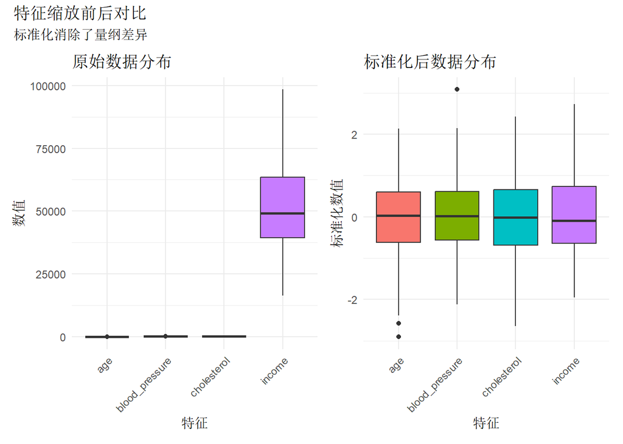

```r
# 使用caret包的preProcess函数
preproc_std <- caret::preProcess(medical_data, method = c("center", "scale"))
medical_data_std2 <- predict(preproc_std, medical_data)

# 可视化对比
viz_data <- data.frame(
  特征 = rep(names(medical_data), each = nrow(medical_data)),
  原始值 = unlist(medical_data),
  标准化后 = unlist(medical_data_std)
)

viz_data$特征 <- factor(viz_data$特征, levels = names(medical_data))

p1 <- ggplot2::ggplot(viz_data, ggplot2::aes(x = 特征, y = 原始值, fill = 特征)) +
  ggplot2::geom_boxplot() +
  ggplot2::labs(title = "原始数据分布", y = "数值") +
  ggplot2::theme_minimal() +
  ggplot2::theme(legend.position = "none", axis.text.x = ggplot2::element_text(angle = 45, hjust = 1))

p2 <- ggplot2::ggplot(viz_data, ggplot2::aes(x = 特征, y = 标准化后, fill = 特征)) +
  ggplot2::geom_boxplot() +
  ggplot2::labs(title = "标准化后数据分布", y = "标准化数值") +
  ggplot2::theme_minimal() +
  ggplot2::theme(legend.position = "none", axis.text.x = ggplot2::element_text(angle = 45, hjust = 1))

p1 + p2 + patchwork::plot_annotation(
  title = "特征缩放前后对比",
  subtitle = "标准化消除了量纲差异"
)
```

### 归一化（Min-Max Normalization）

**公式**：

$$x_{scaled} = \frac{x - x_{min}}{x_{max}
- x_{min}}$$

**特点**： 1. 转换后数据在[0, 1]范围内 2. 对异常值敏感 3. 适用于有明确边界的数据

```r
# 归一化实现
scale_minmax <- function(x) {
  (x - min(x)) / (max(x) - min(x))
}

# 应用归一化
medical_data_norm <- as.data.frame(lapply(medical_data, scale_minmax))

# 查看归一化后的数据范围
summary(medical_data_norm)
```

```
##       age         blood_pressure    cholesterol         income
##  Min.   :0.0000   Min.   :0.0000   Min.   :0.0000   Min.   :0.0000
##  1st Qu.:0.4525   1st Qu.:0.2979   1st Qu.:0.3866   1st Qu.:0.2801
##  Median :0.5823   Median :0.4096   Median :0.5194   Median :0.3988
##  Mean   :0.5761   Mean   :0.4069   Mean   :0.5212   Mean   :0.4179
##  3rd Qu.:0.6962   3rd Qu.:0.5239   3rd Qu.:0.6502   3rd Qu.:0.5743
##  Max.   :1.0000   Max.   :1.0000   Max.   :1.0000   Max.   :1.0000
```

```r
# 使用caret包
preproc_norm <- caret::preProcess(medical_data, method = "range")
medical_data_norm2 <- predict(preproc_norm, medical_data)
```

### 鲁棒缩放（Robust Scaling）

**公式**：

$$x_{scaled} = \frac{x - Q_2}{IQR} =
\frac{x - Q_2}{Q_3 - Q_1}$$

**特点**： 1. 使用中位数和四分位距，对异常值不敏感 2. 适用于有异常值的数据 3. 结果没有固定范围

```r
# 鲁棒缩放实现
scale_robust <- function(x) {
  (x - median(x)) / IQR(x)
}

# 添加异常值演示
medical_data_outlier <- medical_data
medical_data_outlier$cholesterol[1] <- 1000  # 添加异常值

# 对比标准化和鲁棒缩放对异常值的处理
std_with_outlier <- scale_standard(medical_data_outlier$cholesterol)
robust_with_outlier <- scale_robust(medical_data_outlier$cholesterol)

cat("标准化 - 均值:", mean(std_with_outlier), "标准差:", sd(std_with_outlier), "\n")
```

```
## 标准化 - 均值: -8.632418e-17 标准差: 1
```

```r
cat("鲁棒缩放 - 均值:", mean(robust_with_outlier), "标准差:", sd(robust_with_outlier), "\n")
```

```
## 鲁棒缩放 - 均值: 0.1125088 标准差: 1.331805
```

### 意义与使用场景

**核心意义**：特征缩放是数据预处理的基础步骤，确保不同特征对模型的贡献均衡。

**举例**：基于患者生理指标预测疾病风险

**为什么需要特征缩放？**

假设模型使用年龄（20-80岁）、血压（80-180 mmHg）、血糖（3-30 mmol/L）三个特征。如果不缩放，血压的数值范围最大，在KNN等距离敏感算法中会主导距离计算，导致模型主要根据血压做决策，忽略其他特征。

**如何选择缩放方法？**

1. 数据近似正态分布：标准化
2. 数据有明确边界（如图像像素值0-255）：归一化
3. 数据有异常值：鲁棒缩放
4. 不确定：先尝试标准化

**需要注意什么？**

缩放参数（均值、标准差、最小值、最大值）必须只从训练集计算，然后应用到测试集。不能在整个数据集上计算缩放参数，否则会造成数据泄露。